# STAT 497 TERM PROJECT

Aybüke Altuntaş 2361095

2023-01-23

## Required libraries:

```r
library(fUnitRoots)
library(caschrono)
library(timetk)
library(fpp2)
library(TSA)
library(xts)
library(tsbox)
library(forecast)
library(gridExtra)
library(fpp2)
library(tseries)
library(dplyr)
library(pdR)
library(ggplot2)
library(lmtest)
library(tseries)
library(tidyverse)
library(tidyquant)
library(anomalize)
library(knitr)
library(kableExtra)
```

### Loading data and converting it into time series form

```r
data <- read.table("tsdata.txt", sep=",")
names(data)<-c("month","HH_spot_price")
data$month <- as.factor(data$month)
# Change Factor to Date format
data$month <- paste(data$month, "01", sep="-")
# Select only relevant columns in a new dataframe
data$month <- as.Date(data$month,format="%Y-%m-%d")
# Convert df to a tibble
df <- as_tibble(data)
class(df)
```

```
## [1] "tbl_df"     "tbl"        "data.frame"
```

### Detecting and Cleaning Anomalies

```r
df_anomalized <- df %>%
  time_decompose(HH_spot_price, merge = TRUE) %>%
  anomalize(remainder) %>%
  clean_anomalies() %>%
  time_recompose()
df_anomalized %>% glimpse()
```

```
## Rows: 291
## Columns: 12
## Index: month
## $ month            <date> 1997-01-01, 1997-02-01, 1997-03-01, 1997-04-01, 1997…
## $ HH_spot_price    <dbl> 3.45, 2.15, 1.89, 2.03, 2.25, 2.20, 2.19, 2.49, 2.88,…
## $ observed         <dbl> 3.45, 2.15, 1.89, 2.03, 2.25, 2.20, 2.19, 2.49, 2.88,…
## $ season           <dbl> 0.23814241, -0.19237527, -0.06330126, 0.05861636, 0.0…
## $ trend            <dbl> 2.179001, 2.185725, 2.192449, 2.199173, 2.205897, 2.2…
## $ remainder        <dbl> 1.03285651, 0.15665031, -0.23914756, -0.22778906, -0.…
## $ remainder_l1     <dbl> -3.303884, -3.303884, -3.303884, -3.303884, -3.303884…
## $ remainder_l2     <dbl> 3.502882, 3.502882, 3.502882, 3.502882, 3.502882, 3.5…
## $ anomaly          <chr> "No", "No", "No", "No", "No", "No", "No", "No", "No",…
## $ observed_cleaned <dbl> 3.45, 2.15, 1.89, 2.03, 2.25, 2.20, 2.19, 2.49, 2.88,…
## $ recomposed_l1    <dbl> -0.8867401, -1.3105339, -1.1747360, -1.0460946, -1.03…
## $ recomposed_l2    <dbl> 5.920026, 5.496232, 5.632030, 5.760671, 5.775672, 5.8…
```

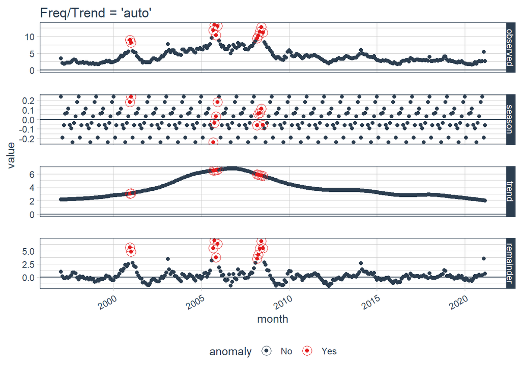

```r
p1 <- df_anomalized %>%
  plot_anomaly_decomposition() +
  ggtitle("Freq/Trend = 'auto'")
p1
```

```r
df_anomalized %>%
  filter(anomaly == "Yes") %>%
  select(month, anomaly, observed, observed_cleaned) %>%
  kable()%>%
  kable_paper(bootstrap_options = "striped", full_width = F)%>%
  kable_styling(fixed_thead = T)
```

| month | anomaly | observed | observed_cleaned |
| --- | --- | --- | --- |
| 2000-12-01 | Yes | 8.90 | 3.245625 |
| 2001-01-01 | Yes | 8.17 | 3.333466 |
| 2005-09-01 | Yes | 11.75 | 6.261272 |
| 2005-10-01 | Yes | 13.42 | 6.491865 |
| 2005-11-01 | Yes | 10.30 | 6.594096 |
| 2005-12-01 | Yes | 13.05 | 6.772974 |
| 2008-03-01 | Yes | 9.41 | 5.884399 |
| 2008-04-01 | Yes | 10.18 | 5.940219 |
| 2008-05-01 | Yes | 11.27 | 5.882398 |
| 2008-06-01 | Yes | 12.69 | 5.860611 |
| 2008-07-01 | Yes | 11.09 | 5.624306 |

The anomalies in the data is removed and replaced by interpolated values.

```r
# Changing tible format to ts class
ts <- as.data.frame(df_anomalized)
x <- df_anomalized %>%
  select(month, observed_cleaned) %>%
  as.ts()
spotprice <-ts(x[,2],start=c(1997,1),frequency=12) #To convert it time series format we use ts() function
head(spotprice)
```

```
##       Jan  Feb  Mar  Apr  May  Jun
## 1997 3.45 2.15 1.89 2.03 2.25 2.20
```

```r
class(spotprice)
```

```
## [1] "ts"
```

### Descriptive statistics

```r
summary(spotprice)
```

```
##    Min. 1st Qu.  Median    Mean 3rd Qu.    Max.
##   1.630   2.645   3.480   3.975   5.235   9.530
```

### Data visualization

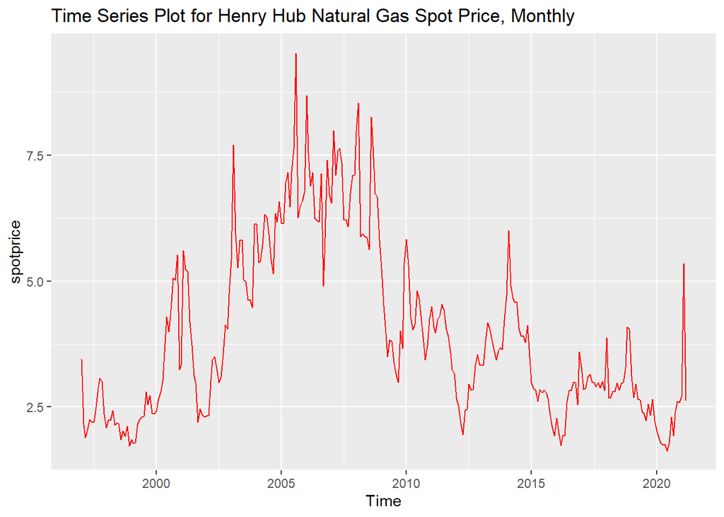

```r
autoplot(spotprice, main="Time Series Plot for Henry Hub Natural Gas Spot Price, Monthly",col="red")
```

### Splitting data into train and test

After cleaning anomalies, the data set is divided into test set and train set. While doing this, the last 12 observations are kept as test set since monthly data is used.

```r
train<-window(spotprice,end=c(2020,3))
test<-window(spotprice,start=c(2020,4))
```

### Transformations

Boxcox transformation is applied for the data set to stabilize the variance.

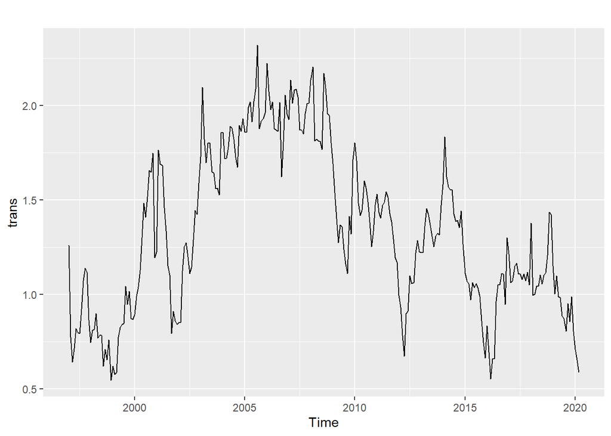

```r
lambda<-BoxCox.lambda(train)
trans<-BoxCox(train,lambda)
autoplot(trans)
```

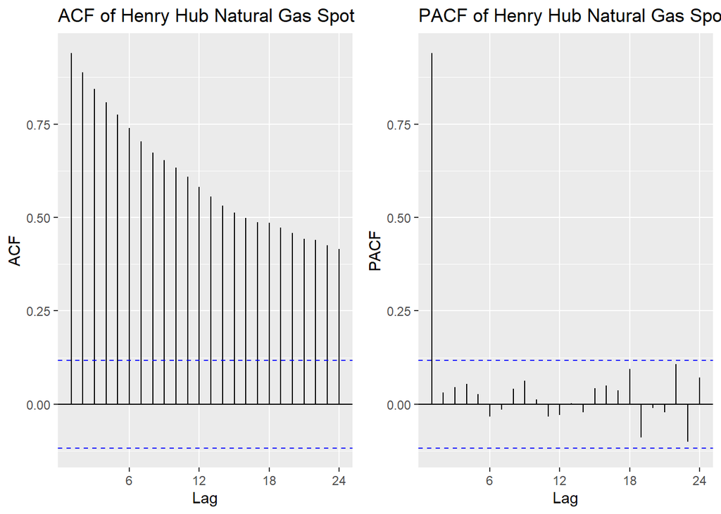

```r
p1<-ggAcf(trans,main="ACF of Henry Hub Natural Gas Spot Price, Monthly")
p2<-ggPacf(trans,main="PACF of Henry Hub Natural Gas Spot Price, Monthly")
grid.arrange(p1,p2,nrow=1)
```

There exists an exponential decay in ACF also lags aren’t in White Noise band

### Box plot across months to explore seasonal effects

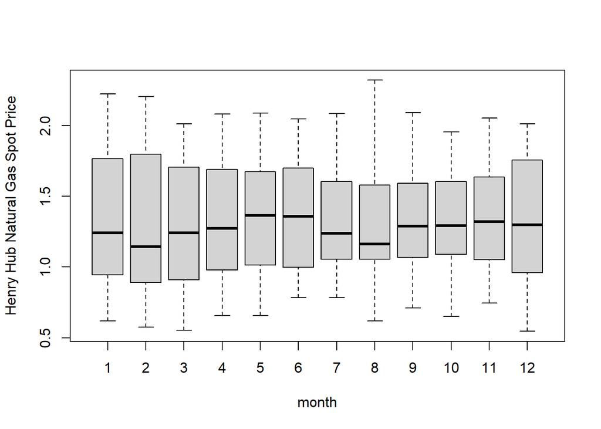

```r
boxplot(trans~cycle(trans),xlab="month",ylab="Henry Hub Natural Gas Spot Price")
```

### Checking trend stationarity and unit root

```r
kpss.test(trans,null=c("Level"))
```

```
##
##  KPSS Test for Level Stationarity
##
## data:  trans
## KPSS Level = 0.89357, Truncation lag parameter = 5, p-value = 0.01
```

Since p value is less than alpha, we reject H0. That means we don’t have enough evidence to claim that the process is stationary.

```r
kpss.test(trans, null=c("Trend"))
```

```
##
##  KPSS Test for Trend Stationarity
##
## data:  trans
## KPSS Trend = 0.8156, Truncation lag parameter = 5, p-value = 0.01
```

Since p value is less than alpha, we reject H0. That means we have enough evidence to claim that the process has stochastic trend.

```r
mean(trans)
```

```
## [1] 1.334423
```

```r
adfTest(trans,lags=4,type="c")
```

```
##
## Title:
##  Augmented Dickey-Fuller Test
##
## Test Results:
##   PARAMETER:
##     Lag Order: 4
##   STATISTIC:
##     Dickey-Fuller: -2.0509
##   P VALUE:
##     0.2933
##
## Description:
##  Mon Jan 23 22:22:03 2023 by user: Asus
```

```r
adfTest(trans,lags=4,type="ct")
```

```
##
## Title:
##  Augmented Dickey-Fuller Test
##
## Test Results:
##   PARAMETER:
##     Lag Order: 4
##   STATISTIC:
##     Dickey-Fuller: -2.1814
##   P VALUE:
##     0.4997
##
## Description:
##  Mon Jan 23 22:22:03 2023 by user: Asus
```

Since p value is greater than α=0.05 , we fail to reject H0. It means that we have non stationary system having unit root.

### Checking Seasonality

```r
out<-HEGY.test(wts=trans, itsd=c(1,0,0), regvar=0, selectlags=list(mode="signf", Pmax=NULL))
out$stats
```

```
##               Stat. p-value
## tpi_1     -1.291375    0.10
## tpi_2     -2.808457    0.01
## Fpi_3:4   24.917475    0.01
## Fpi_5:6   18.458217    0.01
## Fpi_7:8    8.820277    0.01
## Fpi_9:10  19.983898    0.01
## Fpi_11:12  8.922739    0.01
## Fpi_2:12  18.236601      NA
## Fpi_1:12  16.986415      NA
```

The data don’t have any seasonality problem.

To remove unit root, non-stationarity, and stochastic trend, I need to apply differencing. To see how many times I need to apply differencing:

```r
ndiffs(trans)
```

```
## [1] 1
```

```r
nsdiffs(trans)
```

```
## [1] 0
```

One regular difference is needed.

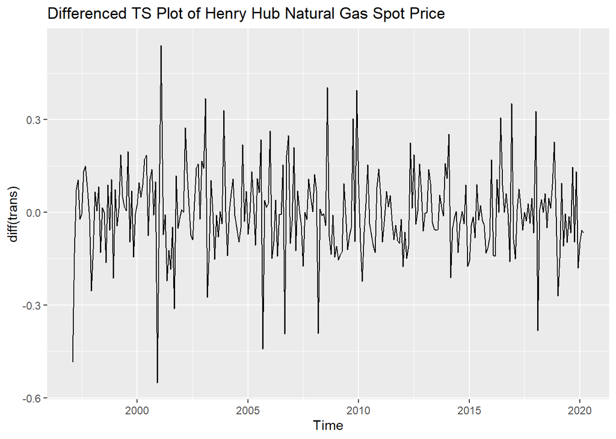

```r
autoplot(diff(trans),main="Differenced TS Plot of Henry Hub Natural Gas Spot Price")
```

#### ACF and PACF of differenced and transformed data

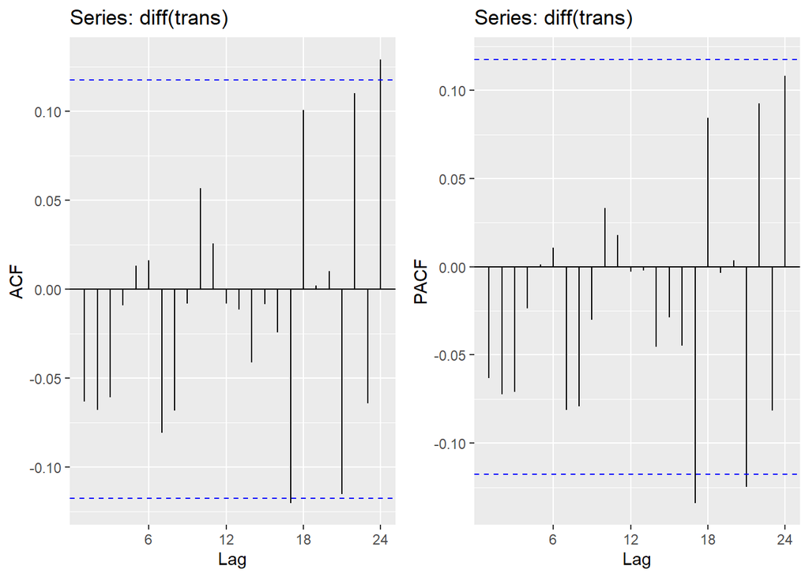

```r
p1<-ggAcf(diff(trans))
p2<-ggPacf(diff(trans))
grid.arrange(p1,p2,nrow=1)
```

```r
adfTest(diff(trans), type="nc")
```

```
##
## Title:
##  Augmented Dickey-Fuller Test
##
## Test Results:
##   PARAMETER:
##     Lag Order: 1
##   STATISTIC:
##     Dickey-Fuller: -13.3232
##   P VALUE:
##     0.01
##
## Description:
##  Mon Jan 23 22:22:04 2023 by user: Asus
```

ADF result shows that unit root, non-stationarity, and stochastic trend are removed.

## MODEL SELECTION

After differencing, we have enough evidence to conclude that differenced series are stationary. Also stochastic trend is removed. After removing non-stationary in the series, we can suggest a model.

```r
fit <- Arima(trans,order=c(0,1,0),seasonal = c(1,0,1))
fit
```

```
## Series: trans
## ARIMA(0,1,0)(1,0,1)[12]
##
## Coefficients:
##          sar1    sma1
##       -0.6442  0.5932
## s.e.   0.3070  0.3193
##
## sigma^2 = 0.01979:  log likelihood = 151.76
## AIC=-297.51   AICc=-297.42   BIC=-286.63
```

```r
fit1 <- Arima(trans,order=c(0,1,0),seasonal = c(0,0,0))
fit1
```

```
## Series: trans
## ARIMA(0,1,0)
##
## sigma^2 = 0.01973:  log likelihood = 151.16
## AIC=-300.33   AICc=-300.31   BIC=-296.7
```

```r
fit2 <- Arima(trans,order=c(1,1,0),seasonal = c(1,0,0))
fit2
```

```
## Series: trans
## ARIMA(1,1,0)(1,0,0)[12]
##
## Coefficients:
##           ar1     sar1
##       -0.0657  -0.0086
## s.e.   0.0611   0.0616
##
## sigma^2 = 0.01979:  log likelihood = 151.75
## AIC=-297.5   AICc=-297.41   BIC=-286.62
```

```r
fit3 <- Arima(trans,order=c(0,1,1),seasonal = c(0,0,0))
fit3
```

```
## Series: trans
## ARIMA(0,1,1)
##
## Coefficients:
##           ma1
##       -0.0787
## s.e.   0.0674
##
## sigma^2 = 0.01971:  log likelihood = 151.85
## AIC=-299.7   AICc=-299.66   BIC=-292.45
```

```r
fit4 <- Arima(trans,order=c(1,1,1),seasonal = c(0,0,0))
fit4
```

```
## Series: trans
## ARIMA(1,1,1)
##
## Coefficients:
##          ar1      ma1
##       0.8432  -0.9280
## s.e.  0.0759   0.0517
##
## sigma^2 = 0.01941:  log likelihood = 154.38
## AIC=-302.76   AICc=-302.68   BIC=-291.88
```

```r
fit5 <- Arima(trans,order=c(0,1,2),seasonal = c(0,0,0))
fit5
```

```
## Series: trans
## ARIMA(0,1,2)
##
## Coefficients:
##           ma1      ma2
##       -0.0850  -0.0856
## s.e.   0.0614   0.0620
##
## sigma^2 = 0.01964:  log likelihood = 152.8
## AIC=-299.59   AICc=-299.5   BIC=-288.71
```

```r
fit6 <- Arima(trans,order=c(1,1,2),seasonal = c(1,0,0))
fit6
```

```
## Series: trans
## ARIMA(1,1,2)(1,0,0)[12]
##
## Coefficients:
##          ar1      ma1     ma2     sar1
##       0.8459  -0.9340  0.0048  -0.0026
## s.e.  0.0901   0.1111  0.0738   0.0634
##
## sigma^2 = 0.01955:  log likelihood = 154.39
## AIC=-298.77   AICc=-298.55   BIC=-280.63
```

```r
fit7 <- auto.arima(trans)
fit7
```

```
## Series: trans
## ARIMA(1,1,1)
##
## Coefficients:
##          ar1      ma1
##       0.8432  -0.9280
## s.e.  0.0759   0.0517
##
## sigma^2 = 0.01941:  log likelihood = 154.38
## AIC=-302.76   AICc=-302.68   BIC=-291.88
```

```r
eacf(trans)
```

```
## AR/MA
##   0 1 2 3 4 5 6 7 8 9 10 11 12 13
## 0 x x x x x x x x x x x  x  x  x
## 1 o o o o o o o o o o o  o  o  o
## 2 x o o o o o o o o o o  o  o  o
## 3 x o o o o o o o o o o  o  o  o
## 4 x x o o o o o o o o o  o  o  o
## 5 x x o x o o o o o o o  o  o  o
## 6 x x o x o o o o o o o  o  o  o
## 7 x x o x x x o o o o o  o  o  o
```

If the ratio between these estimates and their standard errors (s.e) are greater than +2 or less than -2 , we can say that these parameters are significant and the model is significant. After considering the way , we can say that the fourth model ARIMA(1,1,1)(0,0,0)[12] is the only significant model also it has the lowest AIC value. Thus, I’ll continue with it.

## Diagnostic Check

#### 1. Normality of Residuals

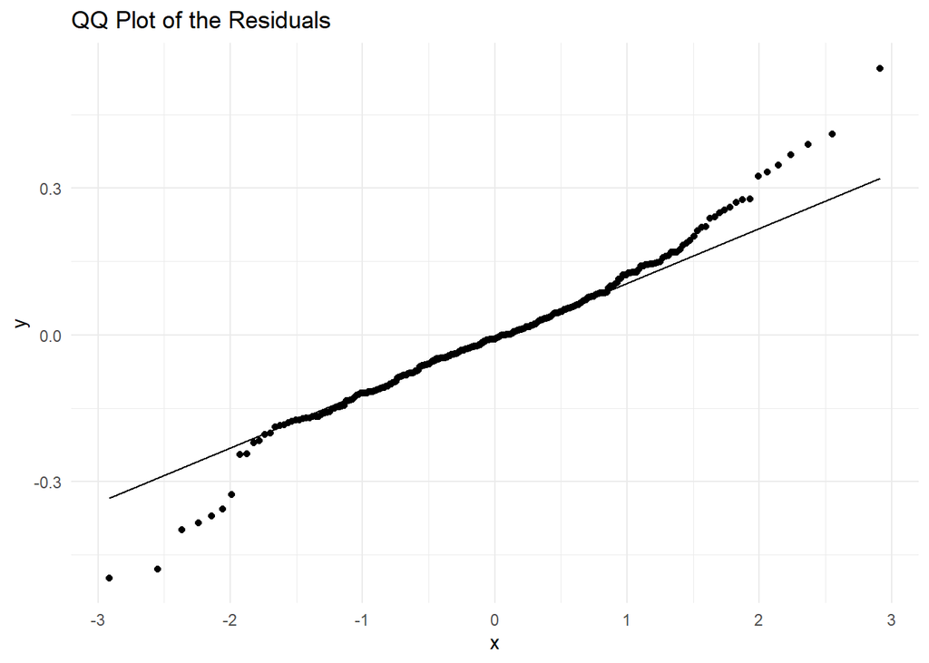

```r
r <- resid(fit4)
ggplot(r, aes(sample = r)) +stat_qq()+geom_qq_line()+ggtitle("QQ Plot of the Residuals")+theme_minimal()
```

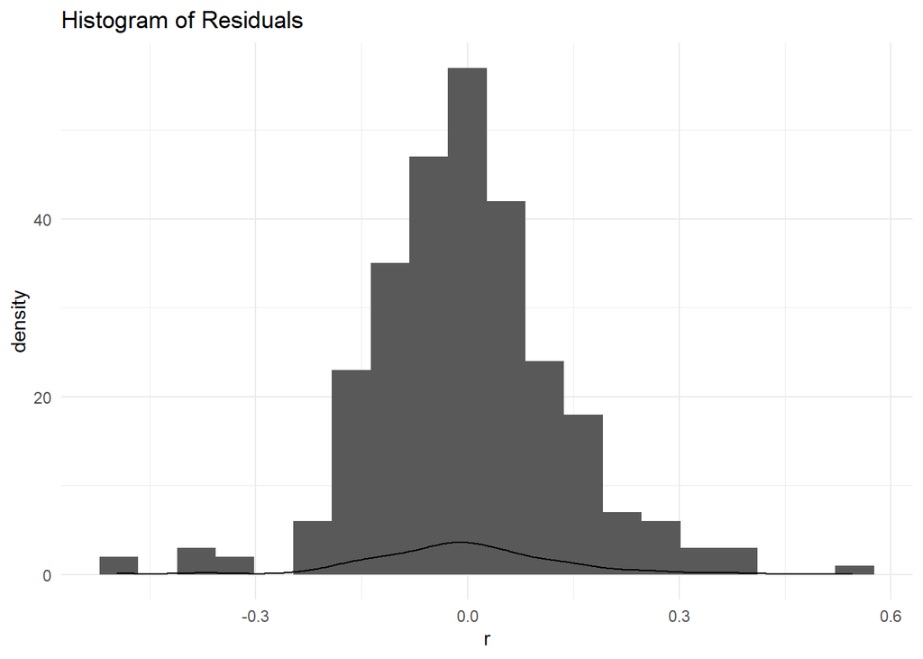

```r
ggplot(r,aes(x=r))+geom_histogram(bins=20)+geom_density()+ggtitle("Histogram of Residuals")+theme_minimal()
```

Since the Q-Q plot shows the most of the residuals of the model lie on 45 degree straight line. This indicates residuals may normally distributed

```r
shapiro.test(r)
```

```
##
##  Shapiro-Wilk normality test
##
## data:  r
## W = 0.97158, p-value = 2.43e-05
```

To be sure about non-normality, Shapiro-Wilk test should be applied. Unfortunately, test result shows that errors do not distributed normally (p<0.05). We have non-normal residuals. But we assume normality.

### Detection of Serial Correlation

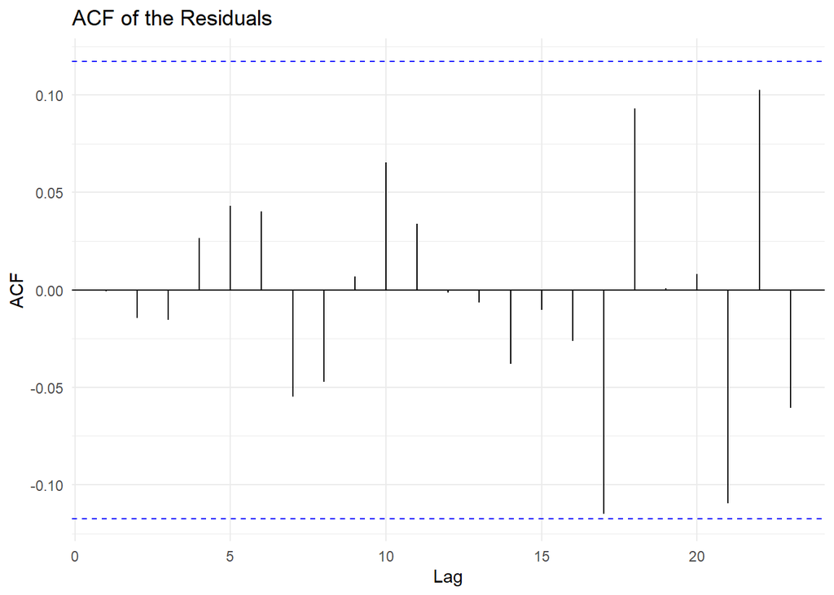

```r
ggAcf(as.vector(r),main="ACF of the Residuals",lag = 23)+theme_minimal()
```

As seen all spikes are in the White Noise. Thus, it can be concluded that our residuals are uncorrelated

```r
Box.test(r,lag=2,type = c("Ljung-Box"))
```

```
##
##  Box-Ljung test
##
## data:  r
## X-squared = 0.058527, df = 2, p-value = 0.9712
```

Since p value is greater than alpha, we have 95% confident that the residuals of the model are uncorrelated, according to results of Box-Ljung Test.

```r
Box.test(r,lag=2,type = c("Box-Pierce"))
```

```
##
##  Box-Pierce test
##
## data:  r
## X-squared = 0.057694, df = 2, p-value = 0.9716
```

Since p value is greater than alpha, we have 95% confident that the residuals of the model are uncorrelated, according to results of Box-Pierce Test.

### 3.Heteroscedasticity

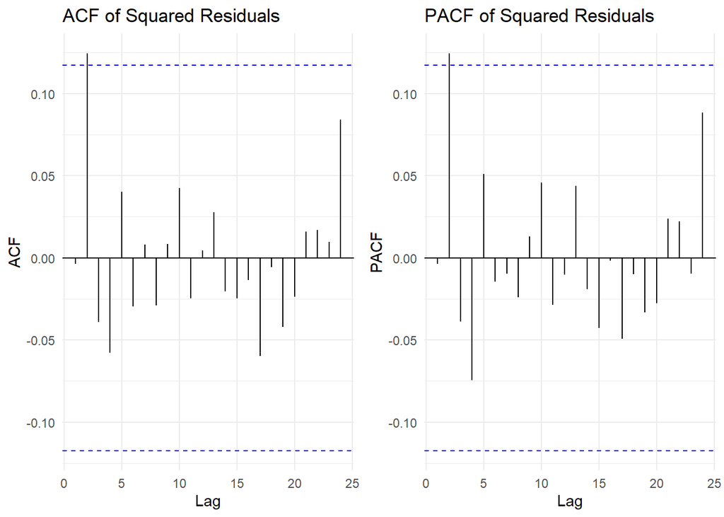

```r
rr=r^2
g1<-ggAcf(as.vector(rr))+theme_minimal()+ggtitle("ACF of Squared Residuals")
g2<-ggPacf(as.vector(rr))+theme_minimal()+ggtitle("PACF of Squared Residuals")  # homoscedasticity check
grid.arrange(g1,g2,ncol=2)
```

```r
m = lm(r ~ trans+zlag(trans)+zlag(trans,2))
bptest(m)
```

```
##
##  studentized Breusch-Pagan test
##
## data:  m
## BP = 2.1151, df = 3, p-value = 0.5489
```

## Forecasting

### ARIMA

```r
f<-forecast(fit4,h=12)
```

Accuracy results of ARIMA model.

```r
accuracy(f,test)
```

```
##                        ME      RMSE       MAE       MPE      MAPE      MASE
## Training set -0.002983954 0.1385727 0.1014079 -1.342508  8.388661 0.3492051
## Test set      1.736239523 1.9689886 1.7362395 68.369841 68.369841 5.9788625
##                       ACF1 Theil's U
## Training set -0.0007799039        NA
## Test set      0.2495228214  2.329277
```

```r
f1<-InvBoxCox(f$mean,lambda)
accuracy(f1,test)
```

```
##                ME      RMSE       MAE      MPE     MAPE     ACF1 Theil's U
## Test set 0.420966 0.9955958 0.5699728 9.558123 18.17501 0.211538  1.090646
```

Forecast plot of ARIMA model.

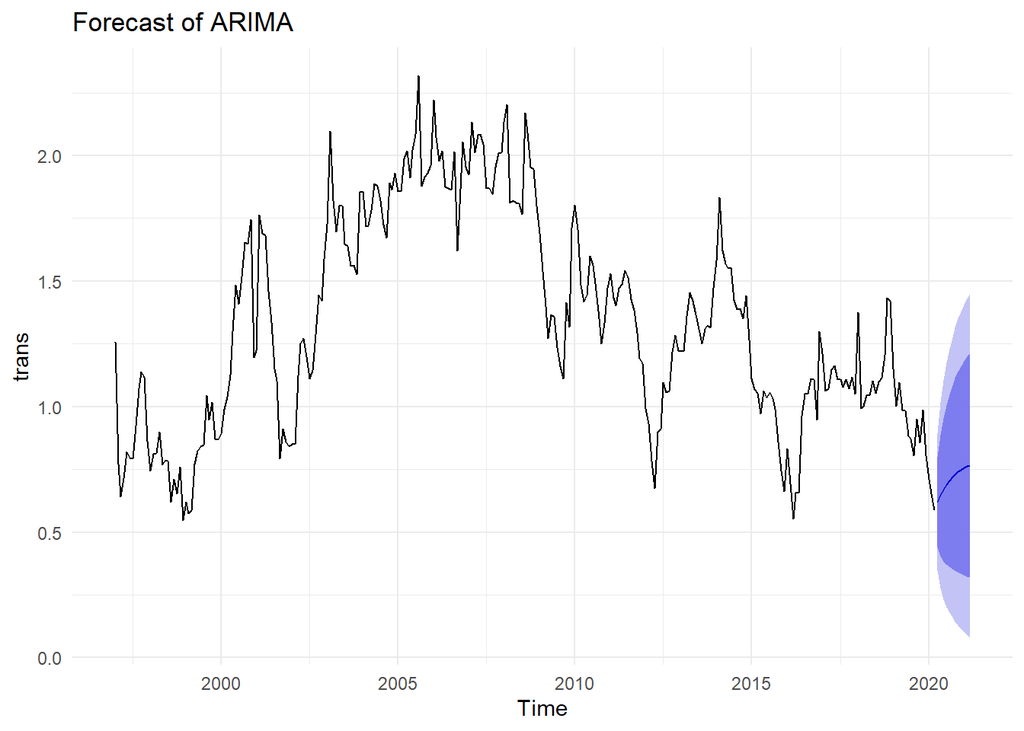

```r
autoplot(f)+theme_minimal()+ggtitle("Forecast of ARIMA")
```

Then, let me apply time series decomposition to analyze whether time series components exhibit additive or multiplicative behavior.

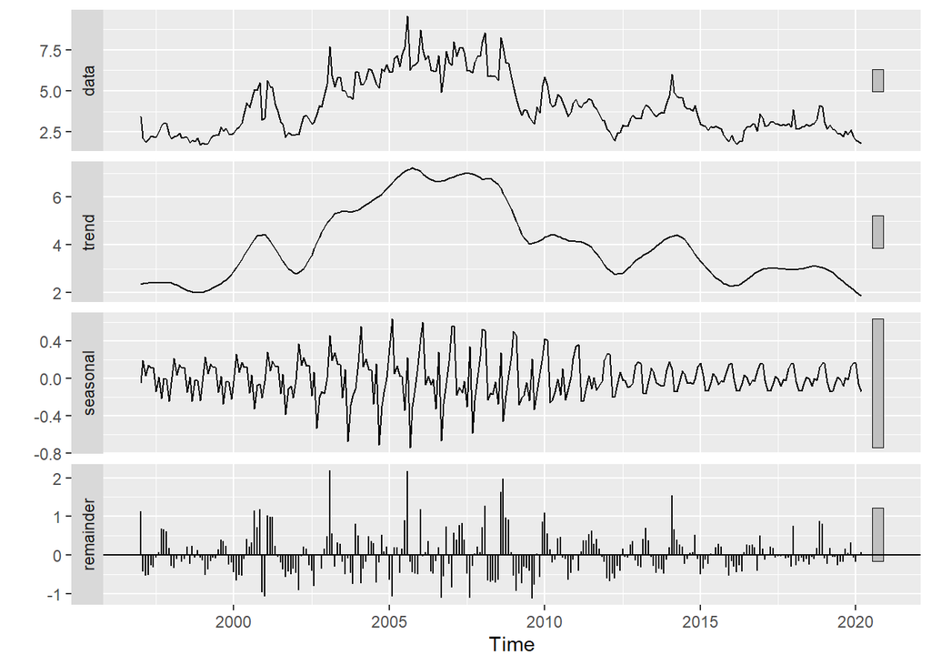

```r
autoplot(stl(train,s.window = 12))
```

The data shows multiplicative behavior.

#### ETS

It is seen that we have exponential smoothing model having multiplicative error. After fitting the model, the residuals of the ETS model is checked by Shapiro-Wilk test and seen that they do not follow normal distribution. (p<0.05)

```r
etsfit<-ets(train, model="MNN") # Simple exponential smoothing with multiplicative errors.
summary(etsfit)
```

```
## ETS(M,N,N)
##
## Call:
##  ets(y = train, model = "MNN")
##
##   Smoothing parameters:
##     alpha = 0.9693
##
##   Initial states:
##     l = 3.3629
##
##   sigma:  0.1389
##
##      AIC     AICc      BIC
## 1206.071 1206.158 1216.964
##
## Training set error measures:
##                        ME     RMSE       MAE       MPE     MAPE      MASE
## Training set -0.005802189 0.640181 0.4080154 -1.184296 9.814944 0.3764989
##                    ACF1
## Training set -0.1179086
```

```r
rets <- etsfit$residuals
shapiro.test(rets)
```

```
##
##  Shapiro-Wilk normality test
##
## data:  rets
## W = 0.94716, p-value = 1.767e-08
```

Accuracy results of ETS model.

```r
etsf <-forecast(etsfit,h=12)
accuracy(etsf,test)
```

```
##                        ME     RMSE       MAE       MPE      MAPE      MASE
## Training set -0.005802189 0.640181 0.4080154 -1.184296  9.814944 0.3764989
## Test set      0.654542220 1.159334 0.7020696 19.197528 22.028605 0.6478394
##                    ACF1 Theil's U
## Training set -0.1179086        NA
## Test set      0.2856833  1.269677
```

Forecast plot of ETS model.

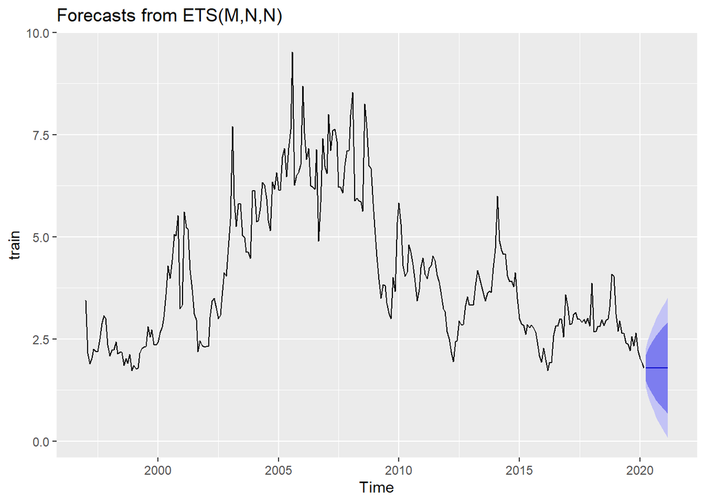

```r
autoplot(etsf)
```

#### NN

```r
nnetarfit<-nnetar(train)
summary(nnetarfit)
```

```
##           Length Class        Mode
## x         279    ts           numeric
## m           1    -none-       numeric
## p           1    -none-       numeric
## P           1    -none-       numeric
## scalex      2    -none-       list
## size        1    -none-       numeric
## subset    279    -none-       numeric
## model      20    nnetarmodels list
## nnetargs    0    -none-       list
## fitted    279    ts           numeric
## residuals 279    ts           numeric
## lags       16    -none-       numeric
## series      1    -none-       character
## method      1    -none-       character
## call        2    -none-       call
```

```r
rnnetar <- nnetarfit$residuals
shapiro.test(rnnetar)
```

```
##
##  Shapiro-Wilk normality test
##
## data:  rnnetar
## W = 0.92648, p-value = 3.977e-10
```

Accuracy results of NN model.

```r
nnetarf <-forecast(nnetarfit,h=12)
accuracy(nnetarf,test)
```

```
##                       ME      RMSE       MAE        MPE      MAPE      MASE
## Training set 0.000323231 0.1886750 0.1260569 -0.5187008  3.770143 0.1163199
## Test set     0.202041527 0.8264739 0.3806446  1.7271098 11.532319 0.3512423
##                       ACF1 Theil's U
## Training set -0.0003985931        NA
## Test set      0.0195761398 0.9060192
```

Forecast plot of NN model.

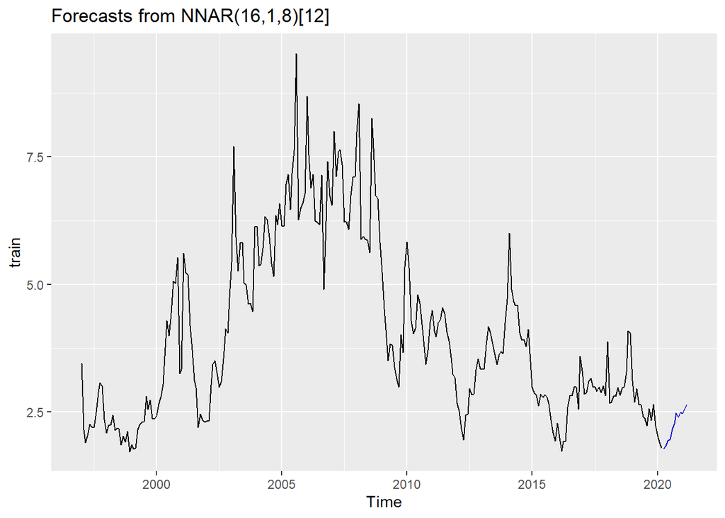

```r
autoplot(nnetarf)
```